# 04 — Price/Cost Pattern Mining & Charge Behaviour

This notebook explores how individual charge types and charge combinations affect shipment margin and loss-making behaviour.

**Goals**

- Identify which charges drive the most revenue, cost, and margin.
- Quantify which charges are most associated with loss-making shipments.
- Understand supplier–charge interactions (which suppliers overuse which charges).
- Build a simple logistic model to estimate how each charge affects loss risk.

**Data source**

Merged on `unique_tracking`.

```python
import os
import pandas as pd
import numpy as np
import matplotlib.pyplot as plt
import seaborn as sns

from sklearn.linear_model import LogisticRegression
from sklearn.preprocessing import OneHotEncoder
from sklearn.compose import ColumnTransformer
from sklearn.pipeline import Pipeline
```

We load the enriched shipments and charges parquet files and merge into a single analytical dataset. Margin and margin percentage are computed dynamically in this notebook

```python
folder = r"C:\Users\lewis\OneDrive\Documents\Jupyter_Notebooks\data"

df_ship = pd.read_parquet(folder + r"\fct_shipments_randomised.parquet")
df_chg  = pd.read_parquet(folder + r"\fct_charges_randomised.parquet")

# Add margin columns to shipment table BEFORE merge
df_ship["margin"] = df_ship["total_sales"] - df_ship["total_costs"]
df_ship["margin_pct"] = np.where(
    df_ship["total_sales"] != 0,
    df_ship["margin"] / df_ship["total_sales"] * 100,
    np.nan
)

# Merge to create the expanded model
df = df_ship.merge(df_chg, on="unique_tracking", how="left")
```

## 1. Charge mix overview

First, understand the overall importance of each `charge_type`:

- How much **revenue** and **cost** do they carry?
- How much **margin** do they contribute?
- How common are they across shipments?

```python
# --- Clean up charge_type ---
df["charge_type"] = df["charge_type"].fillna("BASE")

# --- Baseline metrics ---
baseline_loss_rate = (
    df_ship["is_loss_making"].mean()
    if "is_loss_making" in df_ship.columns
    else (df.groupby("unique_tracking")["margin"].first() < 0).mean()
)

baseline_margin_pct = df["margin"].mean() / df["total_sales"].mean()

# --- Charge mix analysis ---
charge_mix = (
    df.groupby("charge_type")
      .agg(
          shipments=("unique_tracking", "nunique"),
          charge_lines=("charge_type", "size"),
          revenue=("sales_amount", "sum"),
          cost=("cost_amount", "sum"),
          margin=("sales_amount", lambda x: 0),  # placeholder for now
          num_loss_shipments=("is_loss_making", "sum")
      )
      .reset_index()
)

# Compute margin per charge type correctly
charge_mix["margin"] = charge_mix["revenue"] - charge_mix["cost"]

# --- Derived KPIs ---
total_shipments = df["unique_tracking"].nunique()

charge_mix["shipments_share_pct"] = (
    charge_mix["shipments"] / total_shipments * 100
)

charge_mix["loss_rate_pct"] = np.where(
    charge_mix["shipments"] > 0,
    charge_mix["num_loss_shipments"] / charge_mix["shipments"] * 100,
    np.nan
)

charge_mix["margin_per_shipment"] = np.where(
    charge_mix["shipments"] > 0,
    charge_mix["margin"] / charge_mix["shipments"],
    np.nan
)

# --- Sort output nicely ---
charge_mix.sort_values("margin", ascending=False).head(20)
```

|  | charge_type | shipments | charge_lines | revenue | cost | margin | num_loss_shipments | shipments_share_pct | loss_rate_pct | margin_per_shipment |
| --- | --- | --- | --- | --- | --- | --- | --- | --- | --- | --- |
| 6 | Insurance | 3797026 | 4245501 | 1018000.45 | 688634.36 | 329366.09 | 49638 | 41.166729 | 1.307286 | 0.086743 |
| 5 | Fuel_Surcharge | 3798232 | 4245773 | 1011359.22 | 683500.44 | 327858.78 | 49929 | 41.179804 | 1.314533 | 0.086319 |
| 1 | Collection_Fee | 3797273 | 4245030 | 1011111.34 | 683324.15 | 327787.19 | 49852 | 41.169407 | 1.312837 | 0.086322 |
| 9 | Remote_Area | 3795244 | 4242179 | 1014297.08 | 687756.03 | 326541.05 | 49903 | 41.147409 | 1.314883 | 0.086040 |
| 7 | Oversize | 3797979 | 4244567 | 1016804.18 | 690522.45 | 326281.73 | 49898 | 41.177061 | 1.313804 | 0.085909 |
| 3 | Delivery_Attempt | 3798017 | 4246100 | 1012750.44 | 687101.66 | 325648.78 | 49834 | 41.177473 | 1.312106 | 0.085742 |
| 2 | Customs_Clearance | 3797275 | 4243940 | 1010446.06 | 685388.18 | 325057.88 | 49809 | 41.169428 | 1.311704 | 0.085603 |
| 8 | Peak_Surcharge | 3797814 | 4245061 | 1008540.45 | 683810.61 | 324729.84 | 49850 | 41.175272 | 1.312597 | 0.085504 |
| 10 | Saturday_Delivery | 3795038 | 4242579 | 1010349.14 | 686577.15 | 323771.99 | 49777 | 41.145175 | 1.311634 | 0.085315 |
| 4 | Duty_Handling | 3797826 | 4244118 | 1008152.19 | 685771.70 | 322380.49 | 49328 | 41.175402 | 1.298848 | 0.084886 |
| 0 | BASE | 53058 | 53082 | 0.00 | 0.00 | 0.00 | 616 | 0.575246 | 1.160994 | 0.000000 |

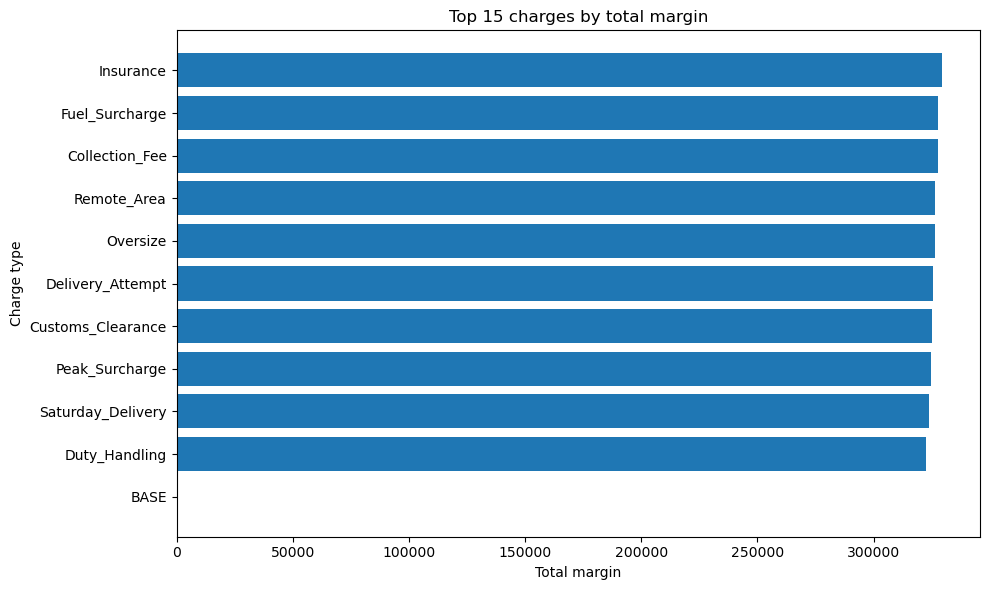

```python
top_n = 15

top_margin = (
    charge_mix
    .sort_values("margin", ascending=False)
    .head(top_n)
    .sort_values("margin", ascending=True)
)

fig, ax = plt.subplots(figsize=(10, 6))
ax.barh(top_margin["charge_type"], top_margin["margin"])
ax.set_xlabel("Total margin")
ax.set_ylabel("Charge type")
ax.set_title(f"Top {top_n} charges by total margin")
plt.tight_layout()
plt.show()
```

## 2. Loss contribution & uplift by charge type

Now focus on **risk**:

- For each `charge_type`, what is the **loss rate** for shipments that include it?
- How does that compare to the **overall loss rate** (uplift)?
- Which charges are systematically associated with loss-making shipments?

```python
# build a table at shipment level: which charges are present per consignment

# create a simple indicator: any line with this charge on the shipment
charge_presence = (
    df
    .groupby(["unique_tracking", "charge_type"])
    .size()
    .reset_index(name="lines")
)

charge_presence["has_charge"] = True

# correct — use df not df_ship
ship_core = df[[
    "unique_tracking",
    "client_code",
    "supplier_code",
    "service_level",
    "dest_country_code",
    "total_sales",
    "total_costs",
    "margin",
    "is_loss_making"
]].drop_duplicates("unique_tracking")

ship_with_charge = charge_presence.merge(ship_core, on="unique_tracking", how="left")

loss_by_charge = (
    ship_with_charge
    .groupby("charge_type")
    .agg(
        shipments=("unique_tracking", "nunique"),
        loss_shipments=("is_loss_making", "sum"),
        avg_margin=("margin", "mean"),
        avg_margin_pct=("margin_pct", "mean") if "margin_pct" in ship_core.columns else ("margin", "mean")
    )
    .reset_index()
)

loss_by_charge["loss_rate_%"] = np.where(
    loss_by_charge["shipments"] > 0,
    loss_by_charge["loss_shipments"] / loss_by_charge["shipments"] * 100,
    np.nan
)

loss_by_charge["loss_uplift_pp"] = loss_by_charge["loss_rate_%"] - baseline_loss_rate * 100

# focus on charges actually used enough to be meaningful
loss_by_charge = loss_by_charge[loss_by_charge["shipments"] >= 100].copy()

loss_by_charge.sort_values("loss_uplift_pp", ascending=False).head(20)
```

|  | charge_type | shipments | loss_shipments | avg_margin | avg_margin_pct | loss_rate_% | loss_uplift_pp |
| --- | --- | --- | --- | --- | --- | --- | --- |
| 9 | Remote_Area | 3795244 | 44751 | 2.207214 | 2.207214 | 1.179134 | 0.003145 |
| 5 | Fuel_Surcharge | 3798232 | 44756 | 2.189710 | 2.189710 | 1.178338 | 0.002349 |
| 7 | Oversize | 3797979 | 44719 | 2.202540 | 2.202540 | 1.177442 | 0.001453 |
| 1 | Collection_Fee | 3797273 | 44688 | 2.193126 | 2.193126 | 1.176845 | 0.000856 |
| 3 | Delivery_Attempt | 3798017 | 44696 | 2.191087 | 2.191087 | 1.176825 | 0.000836 |
| 8 | Peak_Surcharge | 3797814 | 44658 | 2.185970 | 2.185970 | 1.175887 | -0.000102 |
| 2 | Customs_Clearance | 3797275 | 44645 | 2.194844 | 2.194844 | 1.175712 | -0.000277 |
| 10 | Saturday_Delivery | 3795038 | 44538 | 2.187783 | 2.187783 | 1.173585 | -0.002404 |
| 6 | Insurance | 3797026 | 44503 | 2.201407 | 2.201407 | 1.172049 | -0.003940 |
| 4 | Duty_Handling | 3797826 | 44224 | 2.191533 | 2.191533 | 1.164456 | -0.011533 |
| 0 | BASE | 53058 | 616 | 2.192052 | 2.192052 | 1.160994 | -0.014995 |

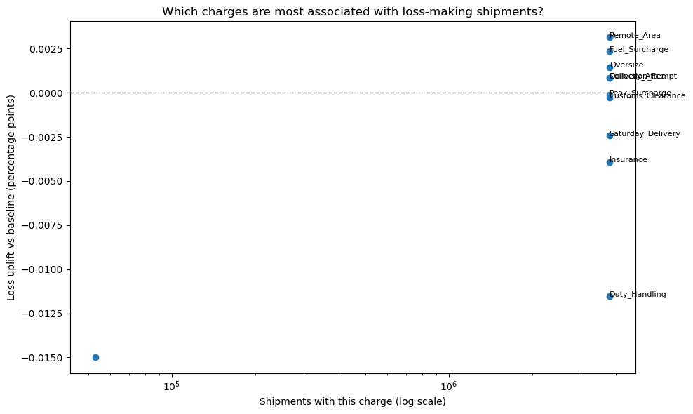

```python
fig, ax = plt.subplots(figsize=(10, 6))

ax.scatter(
    loss_by_charge["shipments"],
    loss_by_charge["loss_uplift_pp"]
)

for _, row in loss_by_charge.sort_values("loss_uplift_pp", ascending=False).head(10).iterrows():
    ax.text(row["shipments"], row["loss_uplift_pp"], row["charge_type"], fontsize=8)

ax.axhline(0, color="grey", linestyle="--", linewidth=1)
ax.set_xscale("log")
ax.set_xlabel("Shipments with this charge (log scale)")
ax.set_ylabel("Loss uplift vs baseline (percentage points)")
ax.set_title("Which charges are most associated with loss-making shipments?")
plt.tight_layout()
plt.show()
```

## 3. Supplier–charge interaction

Next, look at how **charges are used differently by suppliers**:

- Which suppliers rely heavily on certain charges?
- Are there supplier/charge combos that look especially risky?

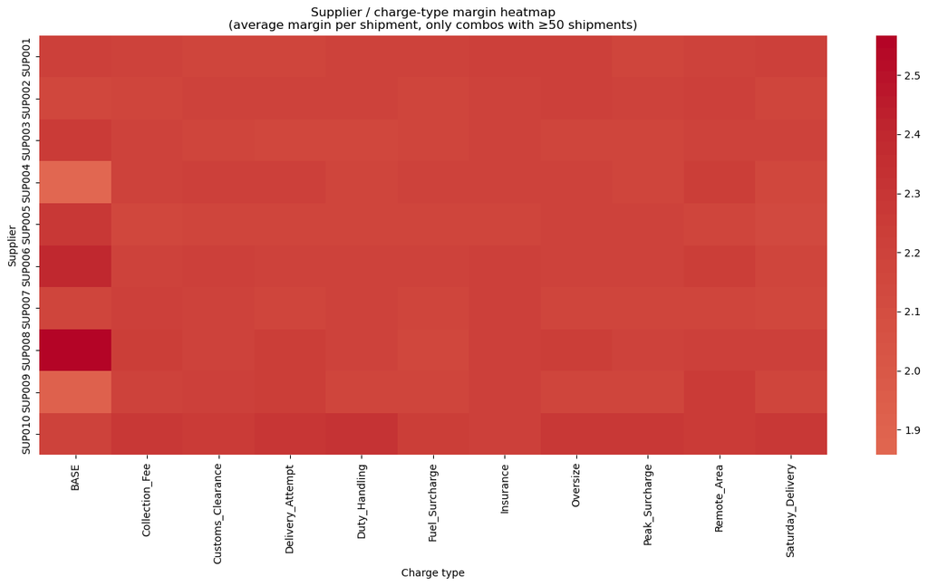

```python
# pivot: supplier vs charge, using margin_per_shipment as shading metric
sup_charge = (
    ship_with_charge
    .groupby(["supplier_code", "charge_type"])
    .agg(
        shipments=("unique_tracking", "nunique"),
        loss_rate=("is_loss_making", "mean"),
        avg_margin=("margin", "mean")
    )
    .reset_index()
)

# filter to reasonably common combos
sup_charge = sup_charge[sup_charge["shipments"] >= 50].copy()

# build a pivot table of avg_margin
pivot_margin = sup_charge.pivot(index="supplier_code", columns="charge_type", values="avg_margin")

plt.figure(figsize=(14, 8))
sns.heatmap(pivot_margin, cmap="coolwarm", center=0)
plt.title("Supplier / charge-type margin heatmap\n(average margin per shipment, only combos with ≥50 shipments)")
plt.xlabel("Charge type")
plt.ylabel("Supplier")
plt.tight_layout()
plt.show()
```

```python
# quick drill-down helper: change this value as you like
supplier = "SUP005"   # e.g. 'Sup001', 'Sup006', etc.

svc_view = (
    sup_charge[sup_charge["supplier_code"] == supplier]
    .sort_values("avg_margin")
)

svc_view
```

|  | supplier_code | charge_type | shipments | loss_rate | avg_margin |
| --- | --- | --- | --- | --- | --- |
| 54 | SUP005 | Saturday_Delivery | 378273 | 0.011611 | 2.144834 |
| 45 | SUP005 | Collection_Fee | 379529 | 0.011770 | 2.150739 |
| 48 | SUP005 | Duty_Handling | 379955 | 0.011328 | 2.170641 |
| 49 | SUP005 | Fuel_Surcharge | 378872 | 0.011402 | 2.176071 |
| 50 | SUP005 | Insurance | 379057 | 0.011502 | 2.179019 |
| 46 | SUP005 | Customs_Clearance | 379670 | 0.011326 | 2.179495 |
| 53 | SUP005 | Remote_Area | 379367 | 0.011580 | 2.181627 |
| 47 | SUP005 | Delivery_Attempt | 379291 | 0.011806 | 2.182806 |
| 51 | SUP005 | Oversize | 379149 | 0.011521 | 2.195864 |
| 52 | SUP005 | Peak_Surcharge | 379687 | 0.011673 | 2.199105 |
| 44 | SUP005 | BASE | 5221 | 0.013024 | 2.271540 |

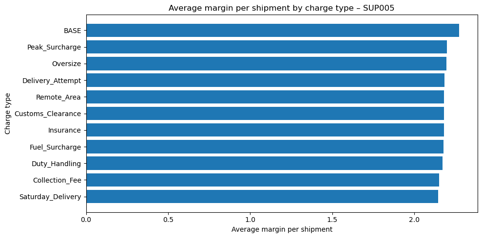

```python
fig, ax = plt.subplots(figsize=(10, 5))
ax.barh(svc_view["charge_type"], svc_view["avg_margin"])
ax.set_xlabel("Average margin per shipment")
ax.set_ylabel("Charge type")
ax.set_title(f"Average margin per shipment by charge type – {supplier}")
plt.tight_layout()
plt.show()
```

## 4. Logistic model: which charges increase loss risk?

We can go a step further and build a simple **logistic regression** that estimates the impact of each charge on the probability that a shipment is loss-making.

High-level idea:

- For each shipment, engineer **binary features** like `has_FuelSurcharge`, `has_ManualFee`, etc.
- Fit a logistic regression to predict `is_loss_making`.
- Look at the coefficients to see which charges have the strongest positive / negative contribution to loss risk.

This is not a full causal model, but it’s a very nice *portfolio-level* signal.

```python
# 1) shipment-level table + outcome
ship_loss = (
    df_ship[["unique_tracking", "margin", "total_sales", "total_costs", "is_loss_making"]]
    .copy()
)

# 2) most common charges
charge_counts = (
    charge_presence
    .groupby("charge_type")["unique_tracking"]
    .nunique()
    .sort_values(ascending=False)
)

top_charges = charge_counts.head(20).index.tolist()
top_charges[:10]
```

```
['Fuel_Surcharge',
 'Delivery_Attempt',
 'Oversize',
 'Duty_Handling',
 'Peak_Surcharge',
 'Customs_Clearance',
 'Collection_Fee',
 'Insurance',
 'Remote_Area',
 'Saturday_Delivery']
```

```python
# keep only top charges
top_presence = charge_presence[charge_presence["charge_type"].isin(top_charges)].copy()

# simple one-hot style pivot: rows = shipments, columns = charge_type (1 = charge present)
charge_wide = (
    top_presence
    .pivot_table(
        index="unique_tracking",
        columns="charge_type",
        values="has_charge",
        aggfunc="max",
        fill_value=False
    )
    .astype(int)
)

charge_wide.head()
```

| charge_type unique_tracking | BASE | Collection_Fee | Customs_Clearance | Delivery_Attempt | Duty_Handling | Fuel_Surcharge | Insurance | Oversize | Peak_Surcharge | Remote_Area | Saturday_Delivery |
| --- | --- | --- | --- | --- | --- | --- | --- | --- | --- | --- | --- |
| TRK00000002 | 0 | 0 | 1 | 0 | 1 | 1 | 0 | 0 | 0 | 0 | 0 |
| TRK00000015 | 0 | 0 | 1 | 1 | 0 | 1 | 1 | 1 | 1 | 0 | 0 |
| TRK00000020 | 0 | 0 | 1 | 1 | 0 | 0 | 0 | 0 | 1 | 1 | 1 |
| TRK00000036 | 0 | 0 | 0 | 1 | 1 | 0 | 1 | 0 | 1 | 1 | 1 |
| TRK00000061 | 0 | 1 | 1 | 0 | 1 | 0 | 0 | 1 | 0 | 0 | 1 |

```python
# join features to outcome
model_df = ship_loss.merge(charge_wide, on="unique_tracking", how="left")
model_df[top_charges] = model_df[top_charges].fillna(0).astype(int)

# sample for speed
sample_n = min(200_000, len(model_df))
model_sample = model_df.sample(sample_n, random_state=42).copy()

X = model_sample[top_charges]
y = model_sample["is_loss_making"].astype(int)

X.shape, y.mean()
```

```
((200000, 11), np.float64(0.01189))
```

```python
logit = LogisticRegression(
    penalty="l2",
    C=1.0,
    max_iter=1000,
    solver="lbfgs"
)

logit.fit(X, y)

# extract coefficients
coef = pd.Series(logit.coef_[0], index=top_charges).sort_values(ascending=False)
coef
```

```
Duty_Handling        0.061912
Remote_Area          0.058411
Collection_Fee       0.044675
Saturday_Delivery    0.002593
Oversize            -0.025825
Insurance           -0.042995
Delivery_Attempt    -0.055175
Peak_Surcharge      -0.055368
Customs_Clearance   -0.070905
Fuel_Surcharge      -0.083505
BASE                -0.315070
dtype: float64
```

```python
# convert coefficients to approximate odds ratios
odds = np.exp(coef)

impact = pd.DataFrame({
    "charge_type": coef.index,
    "coef": coef.values,
    "odds_ratio": odds.values
})

impact["direction"] = np.where(impact["coef"] > 0, "higher_loss_risk", "lower_loss_risk")

impact.sort_values("coef", ascending=False)
```

|  | charge_type | coef | odds_ratio | direction |
| --- | --- | --- | --- | --- |
| 0 | Duty_Handling | 0.061912 | 1.063869 | higher_loss_risk |
| 1 | Remote_Area | 0.058411 | 1.060150 | higher_loss_risk |
| 2 | Collection_Fee | 0.044675 | 1.045688 | higher_loss_risk |
| 3 | Saturday_Delivery | 0.002593 | 1.002596 | higher_loss_risk |
| 4 | Oversize | -0.025825 | 0.974505 | lower_loss_risk |
| 5 | Insurance | -0.042995 | 0.957916 | lower_loss_risk |
| 6 | Delivery_Attempt | -0.055175 | 0.946319 | lower_loss_risk |
| 7 | Peak_Surcharge | -0.055368 | 0.946137 | lower_loss_risk |
| 8 | Customs_Clearance | -0.070905 | 0.931550 | lower_loss_risk |
| 9 | Fuel_Surcharge | -0.083505 | 0.919886 | lower_loss_risk |
| 10 | BASE | -0.315070 | 0.729738 | lower_loss_risk |

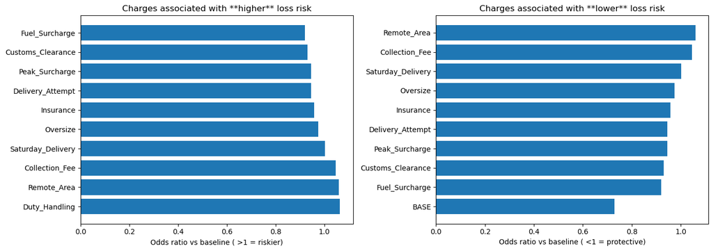

```python
top_k = 10

worst = impact.sort_values("coef", ascending=False).head(top_k)
best  = impact.sort_values("coef", ascending=True).head(top_k)

fig, axes = plt.subplots(1, 2, figsize=(14, 5), sharex=False)

axes[0].barh(worst["charge_type"], worst["odds_ratio"])
axes[0].set_title("Charges associated with **higher** loss risk")
axes[0].set_xlabel("Odds ratio vs baseline ( >1 = riskier)")

axes[1].barh(best["charge_type"], best["odds_ratio"])
axes[1].set_title("Charges associated with **lower** loss risk")
axes[1].set_xlabel("Odds ratio vs baseline ( <1 = protective)")

plt.tight_layout()
plt.show()
```